[figure not shown]

## Открытый курс по машинному обучению. Сессия № 2

</center> Автор материала: программист-исследователь Mail.ru Group, старший преподаватель Факультета Компьютерных Наук ВШЭ Юрий Кашницкий. Материал распространяется на условиях лицензии [Creative Commons CC BY-NC-SA 4.0](https://creativecommons.org/licenses/by-nc-sa/4.0/). Можно использовать в любых целях (редактировать, поправлять и брать за основу), кроме коммерческих, но с обязательным упоминанием автора материала.

# Домашнее задание № 8

## Vowpal Wabbit в задаче прогнозирования популярности статьи на хабре

В этом задании надо побить бенчмарк в [соревновании](https://www.kaggle.com/c/habr-num-bookmarks) на Kaggle Inclass. Как это делать – ограничений нет (кроме, конечно, ручной разметки), прочитать правила можно [тут](https://www.kaggle.com/c/habr-num-bookmarks/rules). Ниже описаны инструкции, как это сделать с Vowpal Wabbit.

Дедлайн: 31 октября 23:59 UTC +3. Решение надо будет загрузить по [ссылке](https://www.dropbox.com/request/g5WOPrxwvcYwADZCuoY7). В этом соревновании нет задачи победить. Цель – побить бенчмарк и продвинуться в [соревновании](https://mlcourse.arktur.io) по прогнозу популярности статьи на Medium.

```python
import numpy as np
import pandas as pd
import json
from tqdm import tqdm_notebook
from sklearn.metrics import mean_absolute_error
import matplotlib.pyplot as plt
```

Посмотрим на одну из строчек в JSON-файле: считаем ее с помощью библиотеки json. Эта строчка соответствует [7-ой статье](https://habrahabr.ru/post/7/) на Хабре.

```python
!head -1 ../../data/train.json > ../../data/train1.json
```

```python
with open('../../data/train1.json') as inp_json:
    first_json = json.load(inp_json)
```

```python
first_json.keys()
```

```
dict_keys(['_timestamp', 'domain', 'title', 'meta_tags', 'tags', 'polling', 'flags', 'url', 'content', '_id', 'link_tags', 'author', 'flow', 'published', 'post_id', 'hubs'])
```

Видим 16 полей, перечислим некоторые из них:

- _id, url - URL статьи
- published – время публикации статьи
- domain – сайт (например, habrahahbr.ru или geektimes.ru)
- title – название статьи
- content – текст статьи
- hubs - перечисление хабов, к которым относится статья
- tags – теги статьи
- author – автор статьи, его ник и ссылка на профиль

```python
first_json['_id']
```

```
'https://habrahabr.ru/post/7/'
```

```python
first_json['_timestamp']
```

```
1493192186.0903192
```

```python
first_json['url']
```

```
'https://habrahabr.ru/post/7/'
```

```python
first_json['domain']
```

```
'habrahabr.ru'
```

```python
first_json['published']
```

```
{'$date': '2006-07-15T01:48:00.000Z'}
```

```python
first_json['title']
```

```
'Самопроизвольное разлогинивание'
```

```python
first_json['content']
```

```
'У меня такое ощущение, что logout время от времени происходит самопроизвольно, несмотря на то, что чекбокс про логине включен.<br>\r\n<br>\r\nВозможно, это происходит при смене IP-адреса, но я не уверен.'
```

```python
first_json['polling']
```

```python
first_json['post_id']
```

```
7
```

```python
first_json['flags']
```

```
[]
```

```python
first_json['hubs']
```

```
[{'id': 'hub/habr',
  'title': 'Хабрахабр',
  'url': 'https://habrahabr.ru/hub/habr/'}]
```

```python
first_json['flow']
```

```python
first_json['tags']
```

```
['логин', 'login']
```

```python
first_json['author']
```

```
{'name': 'Павел Титов',
 'nickname': '@ptitov',
 'url': 'https://habrahabr.ru/users/ptitov'}
```

```python
first_json['link_tags']
```

```
{'alternate': 'https://habrahabr.ru/rss/post/7/',
 'apple-touch-icon-precomposed': '/images/favicons/apple-touch-icon-152x152.png',
 'canonical': 'https://habrahabr.ru/post/7/',
 'icon': '/images/favicons/favicon-16x16.png',
 'image_src': 'https://habrahabr.ru/i/habralogo.jpg',
 'stylesheet': 'https://habracdn.net/habr/styles/1493134745/_build/global_main.css'}
```

```python
first_json['meta_tags']
```

```
{'al:android:app_name': 'Habrahabr',
 'al:android:package': 'ru.habrahabr',
 'al:android:url': 'habrahabr://post/7',
 'al:windows_phone:app_id': '460a6bd6-8955-470f-935e-9ea1726a6060',
 'al:windows_phone:app_name': 'Habrahabr',
 'al:windows_phone:url': 'habrahabr://post/7',
 'apple-mobile-web-app-title': 'Хабрахабр',
 'application-name': 'Хабрахабр',
 'description': 'У меня такое ощущение, что logout время от времени происходит самопроизвольно, несмотря на то, что чекбокс про логине включен.\r\n\r\nВозможно, это происходит при смене IP-адреса, но я не уверен.',
 'fb:app_id': '444736788986613',
 'keywords': 'логин, login',
 'msapplication-TileColor': '#FFFFFF',
 'msapplication-TileImage': 'mstile-144x144.png',
 'og:description': 'У меня такое ощущение, что logout время от времени происходит самопроизвольно, несмотря на то, что чекбокс про логине включен.  Возможно, это происходит при...',
 'og:image': 'https://habrahabr.ru/i/habralogo.jpg',
 'og:title': 'Самопроизвольное разлогинивание',
 'og:type': 'article',
 'og:url': 'https://habrahabr.ru/post/7/',
 'pocket-site-verification': 'ed24b2b9721edf0a282c5b4a3232c4',
 'referrer': 'unsafe-url',
 'robots': 'noindex',
 'twitter:card': 'summary',
 'twitter:site': '@habrahabr',
 'viewport': 'width=1024',
 'yandex-verification': '67d46b975fa41645'}
```

Загрузим ответы на обучающей выборке.

```python
import re
from datetime import datetime
```

```python
# Функция конвертации элемента словаря в namespace для VW
def toVWString(d, argName):
    elem = d[argName]
    if type(elem) == list:
        if (len(elem) == 0):
            return "|" + argName + " "
        if type(elem[0]) != str:
            elem = map(str, elem)
        return "|" + argName + " " + " ".join(elem) + " "
    if type(elem) == dict:
        s = ""
        for key in elem.keys():
            s += key + ":" + str(elem[key]) + " "
        return "|" + argName + " " + s
    return "|" + argName + " " + str(elem) + " "
```

```python
# Конвертация словаря в VW строку
def dictToVWString(d, l=None, value=None):
    if l == None:
        l = d.keys()

    out = "" if value == None else str(value) + " "
    for elem in l:
        out += toVWString(d, elem)
    return out
```

```python
dictToVWString(first_json, ["title", "tags", "domain", "flow", "author", "hubs"])
```

```
"|title Самопроизвольное разлогинивание |tags логин login |domain habrahabr.ru |flow None |author url:https://habrahabr.ru/users/ptitov name:Павел Титов nickname:@ptitov |hubs {'url': 'https://habrahabr.ru/hub/habr/', 'id': 'hub/habr', 'title': 'Хабрахабр'} "
```

```python
train_target = pd.read_csv('../../data/train_target.csv',
                          index_col='url')
```

```python
train_target_dict = train_target.to_dict()["target"]
```

```python
import math
import pandas as pd
import seaborn as sns
%matplotlib inline
```

```python
train_list = []
with open("../../data/train.json") as train_json:
    for line in tqdm_notebook(train_json):
        data_json = json.loads(line)

        wc = len(data_json["content"].split())
        if wc == 0:
            wc = 1

        imgc = data_json["content"].count("img")

        isCompany = 1 if "company" in data_json["url"] else 0

        date = datetime.strptime(data_json["published"]["$date"], "%Y-%m-%dT%H:%M:%S.%fZ")
        train_list.append([date, round(len(data_json["content"]) / 10**6, 2), imgc,
                           wc, train_target_dict[data_json["_id"]]])
```

```python
df = pd.DataFrame(data=train_list, columns=["date", "content_length", "imgCount", "words", "target"])
```

```python
df["hour"] = df.date.apply(lambda d: d.hour)
df["month"] = df.date.apply(lambda d: d.month)
df["weekday"] = df.date.apply(lambda d: d.weekday())
df["year"] = df.date.apply(lambda d: d.year)
df["day"] = df.date.apply(lambda d: d.day)
```

```python
df["short"] = df.words.apply(lambda x: int(x < 450))
df["long"] = df.words.apply(lambda x: int(x >= 450))
df["log_words"] = df.words.apply(lambda x: np.log(x))
```

```python
df.describe()
```

|  | content_length | imgCount | words | target | hour | month | weekday | year | day | short | long | log_words |
| --- | --- | --- | --- | --- | --- | --- | --- | --- | --- | --- | --- | --- |
| count | 120000.000000 | 120000.000000 | 120000.000000 | 120000.000000 | 120000.000000 | 120000.000000 | 120000.000000 | 120000.000000 | 120000.000000 | 120000.000000 | 120000.000000 | 120000.000000 |
| mean | 0.006412 | 4.136758 | 800.801375 | 2.828131 | 13.579542 | 6.599425 | 2.443000 | 2012.157783 | 15.927617 | 0.485908 | 0.514092 | 5.999857 |
| std | 0.009808 | 11.265165 | 1006.916799 | 1.696940 | 5.617905 | 3.513771 | 1.790548 | 3.280202 | 8.695327 | 0.499803 | 0.499803 | 1.397662 |
| min | 0.000000 | 0.000000 | 1.000000 | 0.000000 | 0.000000 | 1.000000 | 0.000000 | 2006.000000 | 1.000000 | 0.000000 | 0.000000 | 0.000000 |
| 25% | 0.000000 | 0.000000 | 189.000000 | 1.609438 | 11.000000 | 3.000000 | 1.000000 | 2009.000000 | 9.000000 | 0.000000 | 0.000000 | 5.241747 |
| 50% | 0.000000 | 1.000000 | 473.500000 | 2.944439 | 14.000000 | 7.000000 | 2.000000 | 2013.000000 | 16.000000 | 0.000000 | 1.000000 | 6.160151 |
| 75% | 0.010000 | 4.000000 | 1077.000000 | 4.127134 | 17.000000 | 10.000000 | 4.000000 | 2015.000000 | 23.000000 | 1.000000 | 1.000000 | 6.981935 |
| max | 0.350000 | 1417.000000 | 55216.000000 | 9.080687 | 23.000000 | 12.000000 | 6.000000 | 2016.000000 | 31.000000 | 1.000000 | 1.000000 | 10.919008 |

```python
df.head()
```

|  | date | content_length | imgCount | words | target | hour | month | weekday | year | day | short | long | log_words |
| --- | --- | --- | --- | --- | --- | --- | --- | --- | --- | --- | --- | --- | --- |
| 0 | 2006-07-15 01:48:00 | 0.0 | 0 | 30 | 0.693147 | 1 | 7 | 5 | 2006 | 15 | 1 | 0 | 3.401197 |
| 1 | 2006-07-15 14:23:00 | 0.0 | 0 | 144 | 1.098612 | 14 | 7 | 5 | 2006 | 15 | 1 | 0 | 4.969813 |
| 2 | 2006-07-04 01:54:00 | 0.0 | 0 | 40 | 0.000000 | 1 | 7 | 1 | 2006 | 4 | 1 | 0 | 3.688879 |
| 3 | 2007-01-11 03:37:00 | 0.0 | 0 | 114 | 0.000000 | 3 | 1 | 3 | 2007 | 11 | 1 | 0 | 4.736198 |
| 4 | 2007-07-30 16:18:00 | 0.0 | 0 | 166 | 0.000000 | 16 | 7 | 0 | 2007 | 30 | 1 | 0 | 5.111988 |

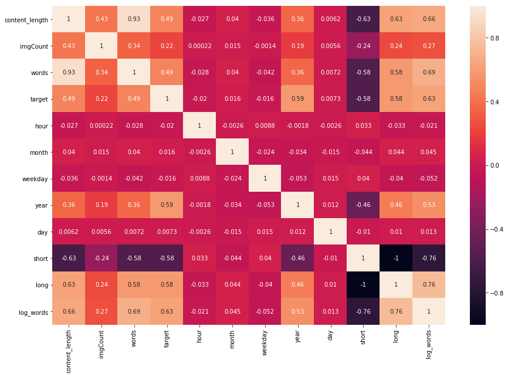

```python
plt.subplots(figsize=(15,10))
sns.heatmap(df.drop("date", axis=1).corr(), annot=True)
```

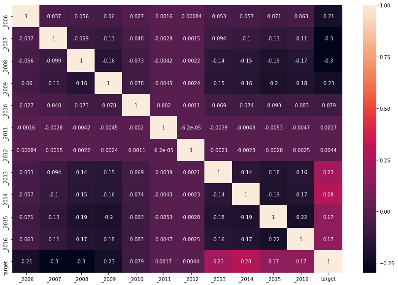

```python
plt.subplots(figsize=(15,10))
sns.heatmap(pd.concat([pd.get_dummies(df.year, prefix=""), df.target], axis=1).corr(), annot=True)
```

```python
with open('../../data/train.json') as inp_json, \
     open('../../data/habr_train.vw', 'w') as out_vw:
    for line in tqdm_notebook(inp_json):
        data_json = json.loads(line)

        date = datetime.strptime(data_json["published"]["$date"], "%Y-%m-%dT%H:%M:%S.%fZ")

        wc = len(data_json["content"].split())
        if wc == 0:
            wc = 1

        data_json["author"] = data_json["author"]["nickname"]
        data_json["hubs"] = list(map(lambda x: x["id"].replace(":", "").lower(), data_json["hubs"]))

        imgc = data_json["content"].count("img") # количество изображений в статье

        data_json["title"] = " ".join(re.findall("\w+", data_json["title"].lower()))
        data_json["tags"] = re.findall("\w+", " ".join(data_json["tags"]).lower())

        data_json["num"] = {"words": math.log(wc) / 12}

        s = dictToVWString(data_json, ["title", "tags", "domain", "flow", "author", "hubs", "num"], train_target_dict[data_json["_id"]])

        for i in range(2006, 2018):
            k = 1 if (i == date.year) else 0
            s += "year_" + str(i) + ":" + str(k) + " "

        for i in range(0, 6):
            k = 1 if (i == imgc) else 0
            s += "imgc_" + str(i) + ":" + str(k) + " "

        out_vw.write(s + "\n")
```

Проделайте все то же с тестовой выборкой, вместо ответов подсовывая что угодно, например, единицы.

```python
with open('../../data/test.json') as inp_json, \
     open('../../data/habr_test.vw', 'w') as out_vw:
    for line in tqdm_notebook(inp_json):
        data_json = json.loads(line)

        date = datetime.strptime(data_json["published"]["$date"], "%Y-%m-%dT%H:%M:%S.%fZ")

        wc = len(data_json["content"].split())
        if wc == 0:
            wc = 1

        data_json["author"] = data_json["author"]["nickname"]
        data_json["hubs"] = list(map(lambda x: x["id"].replace(":", "").lower(), data_json["hubs"]))


        imgc = data_json["content"].count("img") # количество изображений в статье

        data_json["title"] = " ".join(re.findall("\w+", data_json["title"].lower()))
        data_json["tags"] = re.findall("\w+", " ".join(data_json["tags"]).lower())

        data_json["num"] = {"words": math.log(wc) / 12}

        s = dictToVWString(data_json, ["title", "tags", "domain", "flow", "author", "hubs", "num"])

        for i in range(2006, 2018):
            k = 1 if (i == date.year) else 0
            s += "year_" + str(i) + ":" + str(k) + " "

        for i in range(0, 6):
            k = 1 if (i == imgc) else 0
            s += "imgc_" + str(i) + ":" + str(k) + " "

        out_vw.write(s + "\n")
```

```python
!rm cache
!vw -d ../../data/habr_train.vw --cache_file cache -f model.vw --ngram 2 --passes 4 --power_t 0.2 -b 26 -l 0.3 > logs.txt
```

```
Generating 2-grams for all namespaces.
final_regressor = model.vw
Num weight bits = 26
learning rate = 0.3
initial_t = 0
power_t = 0.2
decay_learning_rate = 1
creating cache_file = cache
Reading datafile = ../../data/habr_train.vw
num sources = 1
average  since         example        example  current  current  current
loss     last          counter         weight    label  predict features
0.480453 0.480453            1            1.0   0.6931   0.0000       17
0.658544 0.836634            2            2.0   1.0986   0.1839       41
0.357486 0.056429            4            4.0   0.0000   0.1577       45
4.208015 8.058544            8            8.0   4.9698   0.4633       33
4.527209 4.846404           16           16.0   2.3026   1.4731       35
5.503221 6.479233           32           32.0   2.8904   3.3364       21
4.073176 2.643130           64           64.0   0.0000   1.7122       21
2.900770 1.728365          128          128.0   5.1475   3.3619       23
2.305529 1.710288          256          256.0   4.7707   3.4118       37
2.054317 1.803105          512          512.0   3.1355   3.2141       31
1.788325 1.522333         1024         1024.0   6.4785   4.7245       35
1.586221 1.384118         2048         2048.0   5.7236   4.6532       39
1.361997 1.137772         4096         4096.0   3.3322   3.6410       27
1.197441 1.032886         8192         8192.0   4.1589   3.5643       47
1.065296 0.933152        16384        16384.0   2.7081   4.1033       25
0.901884 0.738471        32768        32768.0   4.1744   2.9219       43
0.710047 0.518211        65536        65536.0   1.3863   2.3972       41
0.760132 0.760132       131072       131072.0   4.9200   4.1589       31 h
0.712078 0.664027       262144       262144.0   4.7362   4.6631       37 h

finished run
number of examples per pass = 108000
passes used = 4
weighted example sum = 432000.000000
weighted label sum = 1222074.122463
average loss = 0.685748 h
best constant = 2.828875
total feature number = 15716376
```

```python
!vw -i model.vw -t -d ../../data/habr_test.vw -p test_predict.csv
```

```
Generating 2-grams for all namespaces.
only testing
predictions = test_predict.csv
Num weight bits = 26
learning rate = 0.5
initial_t = 0
power_t = 0.5
using no cache
Reading datafile = ../../data/habr_test.vw
num sources = 1
average  since         example        example  current  current  current
loss     last          counter         weight    label  predict features
    n.a.     n.a.            1            1.0  unknown   0.7951       17
    n.a.     n.a.            2            2.0  unknown   2.6408       39
    n.a.     n.a.            4            4.0  unknown   2.0864       27
    n.a.     n.a.            8            8.0  unknown   2.4317       27
    n.a.     n.a.           16           16.0  unknown   0.0000       25
    n.a.     n.a.           32           32.0  unknown   4.4039       25
    n.a.     n.a.           64           64.0  unknown   1.6428       31
    n.a.     n.a.          128          128.0  unknown   3.5720       31
    n.a.     n.a.          256          256.0  unknown   3.3058       35
    n.a.     n.a.          512          512.0  unknown   0.5603       25
    n.a.     n.a.         1024         1024.0  unknown   1.5591       13
    n.a.     n.a.         2048         2048.0  unknown   4.8605       31
    n.a.     n.a.         4096         4096.0  unknown   1.3949       23
    n.a.     n.a.         8192         8192.0  unknown   2.9382       33
    n.a.     n.a.        16384        16384.0  unknown   1.7279       37
    n.a.     n.a.        32768        32768.0  unknown   3.0566       55

finished run
number of examples per pass = 52913
passes used = 1
weighted example sum = 52913.000000
weighted label sum = 0.000000
average loss = n.a.
total feature number = 1781861
```

```python
sample_sub = pd.read_csv('sample_submission.csv',
                         index_col='url')
```

```python
pred = pd.read_csv("test_predict.csv", header=None, index_col=None, names=["target"])
pred.head()
```

|  | target |
| --- | --- |
| 0 | 0.795110 |
| 1 | 2.640769 |
| 2 | 0.000000 |
| 3 | 2.086423 |
| 4 | 0.000000 |

```python
your_submission = sample_sub.copy()
your_submission['target'] = pred.target.values
your_submission.to_csv('submission.csv')
```

```python
your_submission.head()
```

| url | target |
| --- | --- |
| https://geektimes.ru/post/87455/ | 0.795110 |
| https://geektimes.ru/post/87452/ | 2.640769 |
| https://geektimes.ru/post/87459/ | 0.000000 |
| https://habrahabr.ru/post/87461/ | 2.086423 |
| https://habrahabr.ru/post/5754/ | 0.000000 |

Для получения баллов в #mlcourse_open команда (из 1 человека) должна называться в точном соответствии с тем, как оно записано в рейтинге.